# Lab #4

Braedon Giblin

## Part 1: Cleaning Data

1. The player names and opponent names as factors

   Answer:

   ```r
   defClean <- defense %>%
     mutate(across(Name:Opponent_Opponent, as.factor))

   offClean <- offense %>%
     mutate(across(Name:Opponent_Opponent, as.factor))

   bioClean <- biography %>%
     mutate(across(Name:Position, as.factor)) %>%
     mutate(across(Class:Highschool, as.factor))
   ```

2. All offensive and defensive statistics are numerical.

   Answer:

   ```r
   defClean <- defClean %>%
     #mutate(across(Tackles_Solo:Pass_PB, ~replace_na(.x, 0))) %>%
     mutate(across(Tackles_Solo:Pass_PB, as.numeric))

   offClean <- offClean %>%
     #mutate(across(Receiving_REC:Passing_INT, ~replace_na(.x, 0))) %>%
     mutate(across(Receiving_REC:Passing_INT, as.numeric))
   bioClean <- bioClean %>%
     mutate(Weight=as.numeric(Weight))
   ```

3. Height as numeric

   Answer:

   ```r
   bioClean <- bioClean %>%
     separate(Height, c('height.feet', 'height.inches')) %>%
     mutate(Height=((as.numeric(height.feet) * 12) + as.numeric(height.inches))) %>%
     select(-height.feet) %>% select(-height.inches)

   str(defClean)
   ```

   ```
   ## tibble [372 x 11] (S3: tbl_df/tbl/data.frame)
   ##  $ Name             : Factor w/ 37 levels "Akers, Landen",..: 26 26 26 26 26 26 26 26 26 26 ...
   ##  $ Opponent_Opponent: Factor w/ 11 levels "Baylor","Kansas",..: 4 8 5 10 6 2 1 3 9 11 ...
   ##  $ Tackles_Solo     : num [1:372] 2 6 6 3 7 4 7 4 4 2 ...
   ##  $ Tackles_ASST     : num [1:372] 4 4 5 0 3 1 4 3 9 3 ...
   ##  $ Tackles_TFL      : num [1:372] 1 0 1.5 1 1 0 1.5 2.5 1.5 0 ...
   ##  $ Tackles_Sack     : num [1:372] 0 0 0.5 0 0 0 0 1 0 0 ...
   ##  $ Turnover_FF      : num [1:372] 0 0 0 0 0 0 0 0 0 0 ...
   ##  $ Turnover_FR      : num [1:372] 0 0 0 0 0 0 0 0 0 0 ...
   ##  $ Turnover_INT     : num [1:372] 0 1 0 0 1 0 1 1 0 0 ...
   ##  $ Pass_QBH         : num [1:372] 0 0 1 0 0 0 2 1 0 0 ...
   ##  $ Pass_PB          : num [1:372] 0 0 0 0 0 1 0 0 1 0 ...
   ```

   ```r
   str(offClean)
   ```

   ```
   ## tibble [156 x 12] (S3: tbl_df/tbl/data.frame)
   ##  $ Name             : Factor w/ 16 levels "Akers, Landen",..: 1 1 1 1 1 1 1 1 1 1 ...
   ##  $ Opponent_Opponent: Factor w/ 11 levels "Baylor","Kansas",..: 4 8 5 10 6 2 1 3 9 11 ...
   ##  $ Receiving_REC    : num [1:156] 0 2 1 4 0 6 1 0 1 1 ...
   ##  $ Receiving_YDS    : num [1:156] 0 60 35 34 0 76 11 0 10 2 ...
   ##  $ Receiving_TD     : num [1:156] 0 0 0 0 0 0 0 0 0 1 ...
   ##  $ Rushing_ATT      : num [1:156] NA NA NA NA NA NA NA NA NA NA ...
   ##  $ Rushing_YDS      : num [1:156] NA NA NA NA NA NA NA NA NA NA ...
   ##  $ Rushing_TD       : num [1:156] NA NA NA NA NA NA NA NA NA NA ...
   ##  $ Passing_CMP-ATT  : num [1:156] NA NA NA NA NA NA NA NA NA NA ...
   ##  $ Passing_YDS      : num [1:156] NA NA NA NA NA NA NA NA NA NA ...
   ##  $ Passing_TD       : num [1:156] NA NA NA NA NA NA NA NA NA NA ...
   ##  $ Passing_INT      : num [1:156] NA NA NA NA NA NA NA NA NA NA ...
   ```

   ```r
   str(bioClean)
   ```

   ```
   ## tibble [116 x 7] (S3: tbl_df/tbl/data.frame)
   ##  $ Name      : Factor w/ 116 levels "Akers, Landen",..: 1 2 3 4 5 6 7 8 9 10 ...
   ##  $ Position  : Factor w/ 14 levels "Deep Snapper",..: 14 13 14 2 9 2 3 3 4 14 ...
   ##  $ Weight    : num [1:116] 191 240 208 180 195 199 253 261 288 182 ...
   ##  $ Class     : Factor w/ 8 levels "Freshman","Junior",..: 5 5 3 1 5 5 4 5 5 1 ...
   ##  $ Hometown  : Factor w/ 96 levels "Adel, Iowa","Alpharetta, Ga.",..: 17 65 82 37 60 40 24 45 45 86 ...
   ##  $ Highschool: Factor w/ 100 levels "ADM","Ames","Andover",..: 93 65 4 13 16 52 19 78 78 87 ...
   ##  $ Height    : num [1:116] 72 79 77 72 72 72 75 74 74 74 ...
   ```

## Part 2: Tidying Data

1. Reformat the `offClean` data frame into a tidy format using `pivot_longer`. The type of statistic is added as a new key column named stat

   Answer:

   ```r
   pivOffClean <- offClean %>%
     pivot_longer(Receiving_REC:Passing_INT, names_to='stat', values_to='value') %>%
     drop_na()
   ```

2. Show the distributions of each stat

   Answer:

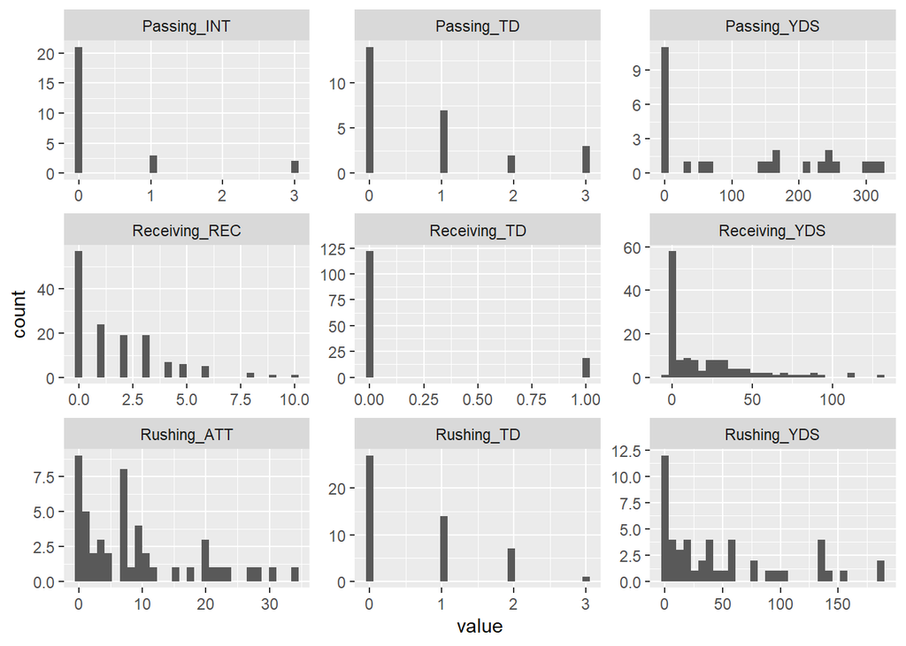

   ```r
   pivOffClean %>%
     ggplot(aes(x=value)) + geom_histogram() + facet_wrap(~stat, scales='free')
   ```

3. Did ISU have better offense against Oregon or Oklahoma

   Answer:

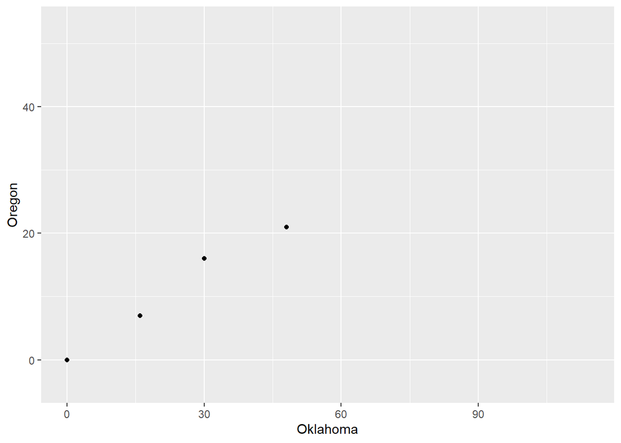

   ```r
   offClean %>%
     filter(Opponent_Opponent %in% c('Oklahoma', 'Oregon')) %>%
     pivot_wider(names_from='Opponent_Opponent', values_from='Receiving_YDS', values_fn = mean) %>%
     ggplot(aes(x=Oklahoma, y=Oregon)) + geom_point()
   ```

   The above plot seems to suggest we do better against Oklahoma, as on average each receiver got more yards against oklahoma than they did against Oregon
4. Separate the hometown column int two cols.

   Answer:

   ```r
   bioClean <- bioClean %>%
     separate(Hometown, c('City', 'State'), sep=', ')

   bioClean %>%
     head(5)
   ```

   ```
   ## # A tibble: 5 x 8
   ##   Name         Position    Weight Class       City     State Highschool   Height
   ##   <fct>        <fct>        <dbl> <fct>       <chr>    <chr> <fct>         <dbl>
   ## 1 Akers, Land~ Wide Recei~    191 Redshirt S~ Cedar R~ Iowa  Washington       72
   ## 2 Allen, Chase Tight End      240 Redshirt S~ Nixa     Mo.   Nixa             79
   ## 3 Anderson, E~ Wide Recei~    208 Redshirt F~ Seffner  Fla.  Armwood          77
   ## 4 Antoine Jr.~ Defensive ~    180 Freshman    Ft. Lau~ Fla.  Cardinal Gi~     72
   ## 5 Assalley, C~ Placekicker    195 Redshirt S~ Napervi~ Ill.  Central          72
   ```

5. How many players from each state

   Answer:

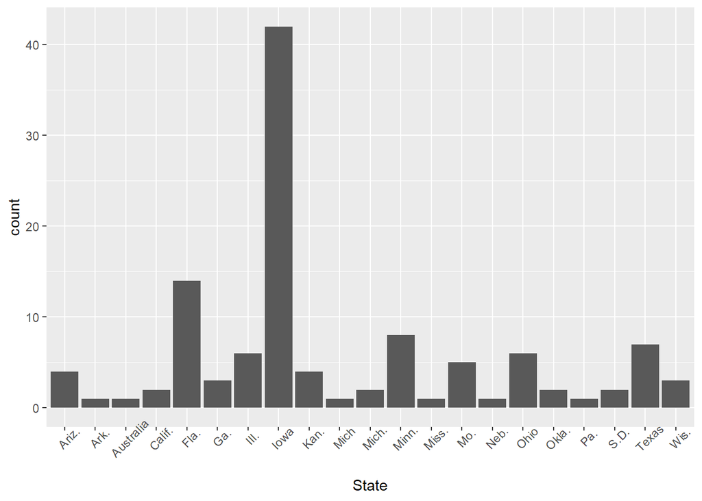

   ```r
   bioClean %>%
     ggplot(aes(x=State)) + geom_bar() + theme(axis.text.x = element_text(angle = 45))
   ```

   ```r
   bioClean %>%
     count(State)
   ```

   ```
   ## # A tibble: 21 x 2
   ##    State         n
   ##  * <chr>     <int>
   ##  1 Ariz.         4
   ##  2 Ark.          1
   ##  3 Australia     1
   ##  4 Calif.        2
   ##  5 Fla.         14
   ##  6 Ga.           3
   ##  7 Ill.          6
   ##  8 Iowa         42
   ##  9 Kan.          4
   ## 10 Mich          1
   ## # ... with 11 more rows
   ```

## Part 3: Joining Dataframes

1. find which states do the ISU players come from.

   Answer:

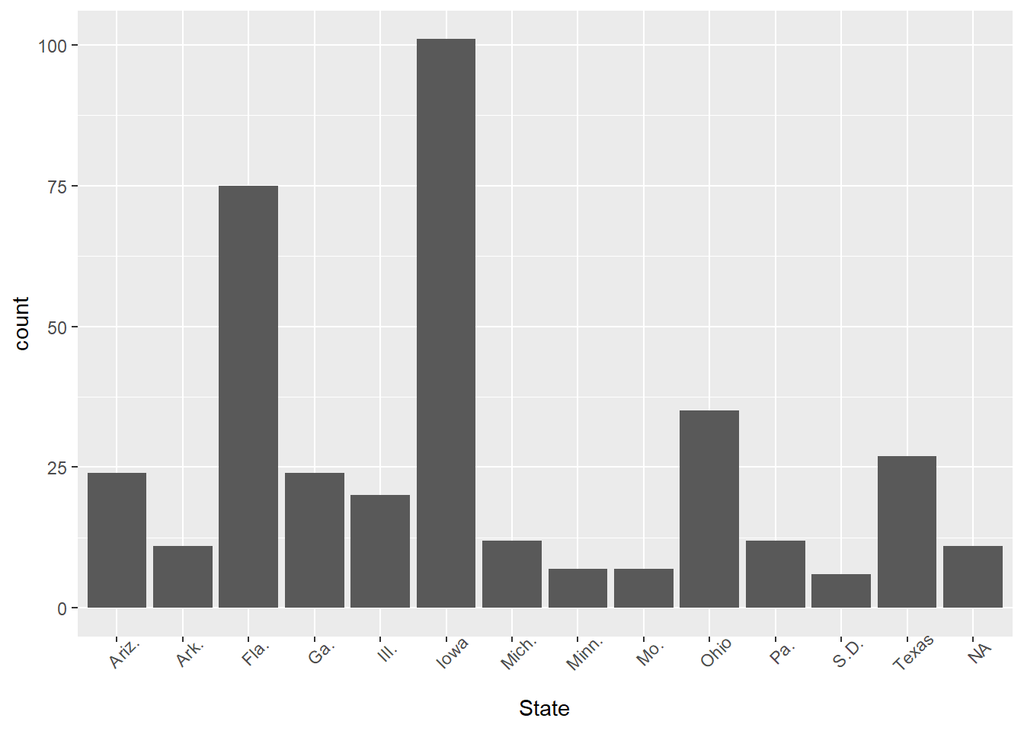

   ```r
   defSub <- defClean %>%
     mutate(Side='defense') %>%
     select(Name, Side) %>%
     left_join(bioClean, by='Name')

   offSub <- offClean %>%
     mutate(Side='offense') %>%
     select(Name, Side) %>%
     left_join(bioClean, by='Name')


   defSub %>%
     ggplot(aes(x=State)) + geom_bar() + theme(axis.text.x = element_text(angle = 45))
   ```

   ```r
   defSub %>%
     count(State)
   ```

   ```
   ## # A tibble: 14 x 2
   ##    State     n
   ##  * <chr> <int>
   ##  1 Ariz.    24
   ##  2 Ark.     11
   ##  3 Fla.     75
   ##  4 Ga.      24
   ##  5 Ill.     20
   ##  6 Iowa    101
   ##  7 Mich.    12
   ##  8 Minn.     7
   ##  9 Mo.       7
   ## 10 Ohio     35
   ## 11 Pa.      12
   ## 12 S.D.      6
   ## 13 Texas    27
   ## 14 <NA>     11
   ```

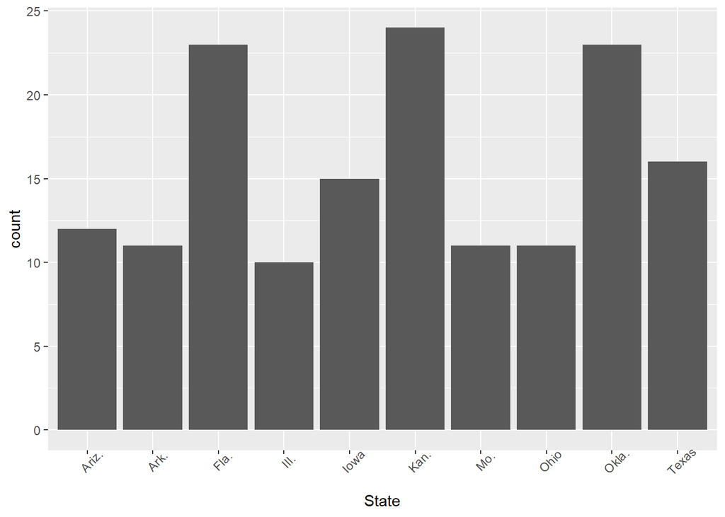

   ```r
   offSub %>%
     ggplot(aes(x=State)) + geom_bar() + theme(axis.text.x = element_text(angle = 45))
   ```

   ```r
   offSub %>%
     count(State)
   ```

   ```
   ## # A tibble: 10 x 2
   ##    State     n
   ##  * <chr> <int>
   ##  1 Ariz.    12
   ##  2 Ark.     11
   ##  3 Fla.     23
   ##  4 Ill.     10
   ##  5 Iowa     15
   ##  6 Kan.     24
   ##  7 Mo.      11
   ##  8 Ohio     11
   ##  9 Okla.    23
   ## 10 Texas    16
   ```

   Answer:

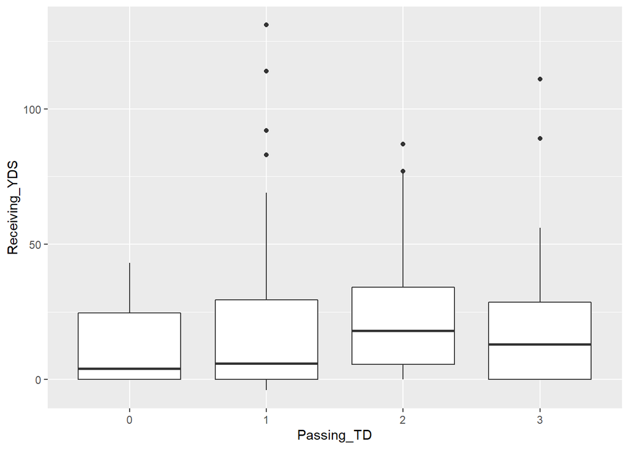

   ```r
   offClean %>%
     select(-Passing_TD) %>%
     left_join(
       offClean %>%
         filter(Name == 'Purdy, Brock') %>%
         select(Opponent_Opponent, Passing_TD),
       by='Opponent_Opponent'
     ) %>%
     mutate(Passing_TD=as.factor(Passing_TD)) %>%
     ggplot(aes(x=Passing_TD, y=Receiving_YDS)) + geom_boxplot()
   ```

   The number of receiving Yards seems to slightly increase on average as the amount of touchdowns thrown by Purdy increase. This would make sense because to throw more touchdowns, the receivers would also need to make more touchdown receptions for more yards.
3. Who improved the most?

   Answer:

   ```r
   s <- offense19 %>%
     mutate(across(Name:Opponent_Opponent, as.factor)) %>%
     mutate(across(Receiving_REC:Passing_INT, as.numeric)) %>%
     select(Name, Receiving_YDS, Opponent_Opponent) %>%
     group_by(Name) %>%
     summarise(mean_yds_2019 = mean(Receiving_YDS, na.rm = TRUE))
   s2 <- offClean %>%
     group_by(Name) %>%
     summarise(mean_yds_2020 = mean(Receiving_YDS, na.rm = TRUE))

   s %>%
     inner_join(s2, by='Name') %>%
     mutate(delta=as.numeric(mean_yds_2020 - mean_yds_2019, na.rm=TRUE)) %>%
     drop_na() %>%
     filter(delta == max(delta))
   ```

   ```
   ## # A tibble: 1 x 4
   ##   Name          mean_yds_2019 mean_yds_2020 delta
   ##   <fct>                 <dbl>         <dbl> <dbl>
   ## 1 Akers, Landen          8.38          22.4  14.0
   ```

   Landen Akers is the most improved player. This is shown by comparing all players average reception yardage in 2019 with 2020. Akers had the greatest improvement of an average of 14 yards per game improvement.